# Lab3

Patty Park

2024-04-17

### Assignment Lab 3:

Due next week: April 23 at 11:59PM

For this assignment you’ll use the article data you downloaded from Nexis Uni in Week 2.

```r
#load in data from assignment 2
tiktok_ca <- read_csv(here("week3/data/tiktok_ca.csv"))
```

1. Create a corpus from your articles.

```r
#create a corpus
corpus <- corpus(x = tiktok_ca, text_field = "text")
```

2. Clean the data as appropriate.

```r
#create stop words to remove from our token
add_stops <- stopwords(kind = quanteda_options("language_stopwords"))

#create a token object from the corpus object
# tokens(corpus)
# create a new token from the corpus that removes punctuations, numbers and url
toks <- tokens(corpus, remove_punct = T, remove_numbers = T, remove_url = T)
#select certain words from the new token object that removes the stopwords from the add_stop object
tok1 <- tokens_select(toks, pattern = add_stops, selection = "remove")

# transform data to a document-feature matrix
dfm1 <- dfm(tok1, tolower = T)
#trim the dfm
dfm2 <- dfm_trim(dfm1, min_docfreq = 2)

#form row with the row_sums function
sel_idx <- slam::row_sums(dfm2) > 0
dfm <- dfm2[sel_idx,]
```

3. Run three models (i.e. with 3 values of k) and select the overall best value for k (the number of topics) - include some justification for your selection: theory, FindTopicsNumber() optimization metrics, interpretability, LDAvis. Select the best single value of k.

```r
set.seed(50)

#find the best number for k
results <- FindTopicsNumber(dfm,
                           topics = seq(from = 2,
                                        to = 20,
                                        by = 1),
                           metrics = c("CaoJuan2009", "Deveaud2014"),
                           method = "Gibbs",
                           verbose = T)
```

```
## fit models... done.
## calculate metrics:
##   CaoJuan2009... done.
##   Deveaud2014... done.
```

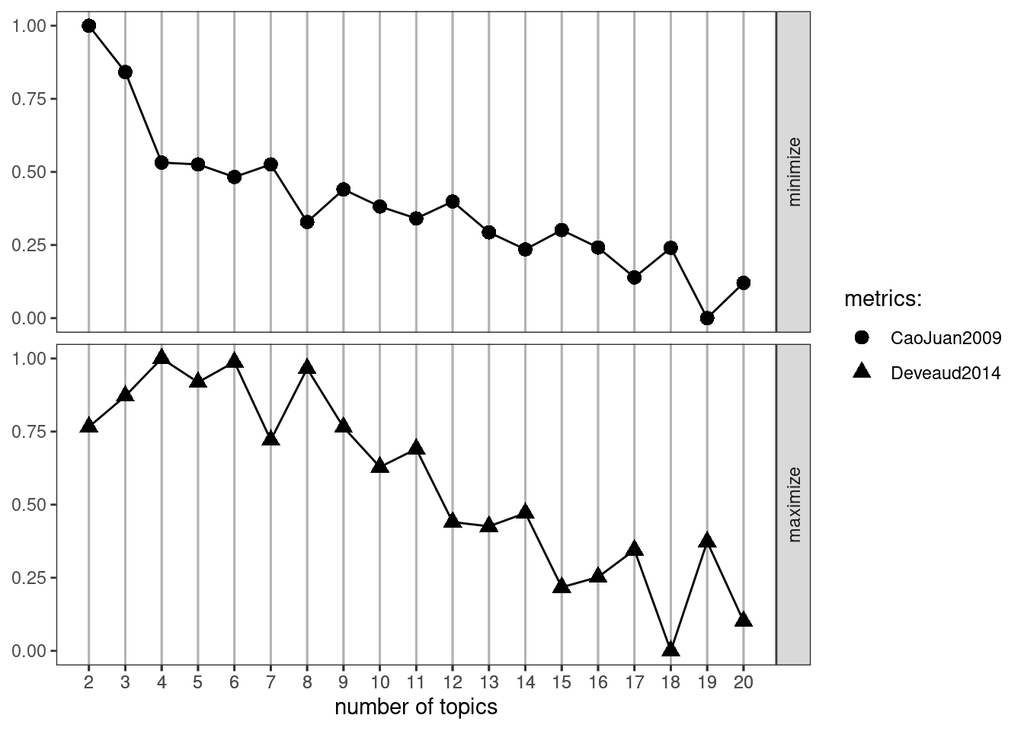

```r
FindTopicsNumber_plot(results)
```

```r
#k as 3
k <- 3

#create the LDA model
topicModel_k3 <- LDA(dfm,
                     k,
                     method = "Gibbs",
                     control = list(iter = 1000),
                     verbose = 25)

#extract the beta and theta term
results_k3 <- posterior(topicModel_k3)
attributes(results_k3) #look at the attributes in the results term
```

```
## $names
## [1] "terms"  "topics"
```

```r
#assign appropriate terms to the appropriate object, will be used in helping to plot the terms
beta_k3 <- results_k3$terms
theta_k3 <- results_k3$topics

# view the dimensions of the beta and theta
# dim(beta_k3)
# dim(theta_k3)

#look at the most appeared terms that pop up per topic
terms(topicModel_k3, 10)
```

```
##       Topic 1    Topic 2    Topic 3
##  [1,] "find"     "social"   "like"
##  [2,] "amazon"   "said"     "just"
##  [3,] "$"        "media"    "video"
##  [4,] "tiktok"   "tiktok"   "photo"
##  [5,] "can"      "people"   "said"
##  [6,] "one"      "internet" "really"
##  [7,] "buy"      "news"     "says"
##  [8,] "products" "can"      "music"
##  [9,] "just"     "will"     "new"
## [10,] "best"     "health"   "time"
```

```r
set.seed(50)

#k as 4
k <- 4

#create the LDA model
topicModel_k4 <- LDA(dfm,
                     k,
                     method = "Gibbs",
                     control = list(iter = 1000),
                     verbose = 25)

#extract the beta and theta term
results_k4 <- posterior(topicModel_k4)
# attributes(results_k4) #look at the attributes in the results term

#assign appropriate terms to the appropriate object, will be used in helping to plot the terms
beta_k4 <- results_k4$terms
theta_k4 <- results_k4$topics

# dim(beta_k4)
# dim(theta_k4)

#look at the most appeared terms that pop up per topic
terms(topicModel_k4, 10)
```

```
##       Topic 1   Topic 2  Topic 3       Topic 4
##  [1,] "find"    "like"   "video"       "social"
##  [2,] "amazon"  "can"    "photo"       "media"
##  [3,] "$"       "one"    "music"       "said"
##  [4,] "tiktok"  "just"   "los"         "tiktok"
##  [5,] "buy"     "people" "new"         "news"
##  [6,] "perfect" "said"   "angeles"     "internet"
##  [7,] "best"    "tiktok" "hollywood"   "u.s"
##  [8,] "skin"    "think"  "sharing"     "trump"
##  [9,] "hair"    "much"   "said"        "public"
## [10,] "walmart" "also"   "celebrities" "company"
```

```r
#k as 5
k <- 5

#create the LDA model
topicModel_k5 <- LDA(dfm,
                     k,
                     method = "Gibbs",
                     control = list(iter = 1000,
                     verbose = 25))
```

[output not shown]

```r
#extract the beta and theta term
results_k5 <- posterior(topicModel_k5)
# attributes(results_k5)#look at the attributes in the results term

#assign appropriate terms to the appropriate object, will be used in helping to plot the terms
beta_k5 <- results_k5$terms
theta_k5 <- results_k5$topics

# dim(beta_k5)
# dim(theta_k5)

#look at the most appeared terms that pop up per topic
terms(topicModel_k5, 10)
```

```
##       Topic 1   Topic 2     Topic 3  Topic 4   Topic 5
##  [1,] "social"  "video"     "like"   "find"    "$"
##  [2,] "media"   "said"      "just"   "amazon"  "one"
##  [3,] "said"    "social"    "music"  "tiktok"  "can"
##  [4,] "tiktok"  "sharing"   "think"  "perfect" "now"
##  [5,] "people"  "hollywood" "kids"   "walmart" "best"
##  [6,] "health"  "photo"     "new"    "set"     "buy"
##  [7,] "company" "tiktok"    "one"    "home"    "products"
##  [8,] "can"     "media"     "said"   "style"   "just"
##  [9,] "u.s"     "also"      "people" "gift"    "product"
## [10,] "trump"   "internet"  "los"    "comfort" "like"
```

4. Plot the top terms in each topic and the distribution of topics across a sample of the documents (constrained by what looks good in the plot).

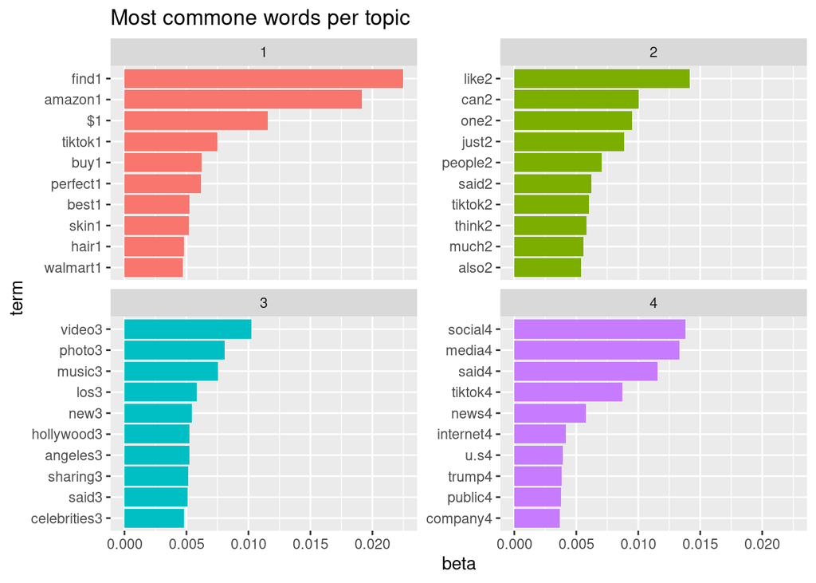

```r
#tidy the topicModel_k4 dataset
topics <- tidy(topicModel_k4, matrix = "beta")
#rearrange the topic to have top ten words from each topic
top_terms <- topics %>%
  group_by(topic) %>%
  top_n(10, beta) %>%
  ungroup() %>%
  arrange(topic, -beta)

#create graph of most common words per topic
top_terms %>%
  mutate(term = reorder_within(term, beta, topic, sep = "")) %>%
  ggplot(aes(term, beta, fill = factor(topic))) +
  geom_col(show.legend = F) +
  facet_wrap(~topic, scales = "free_y") +
  scale_x_reordered()+
  coord_flip() +
  labs(title = "Most commone words per topic")
```

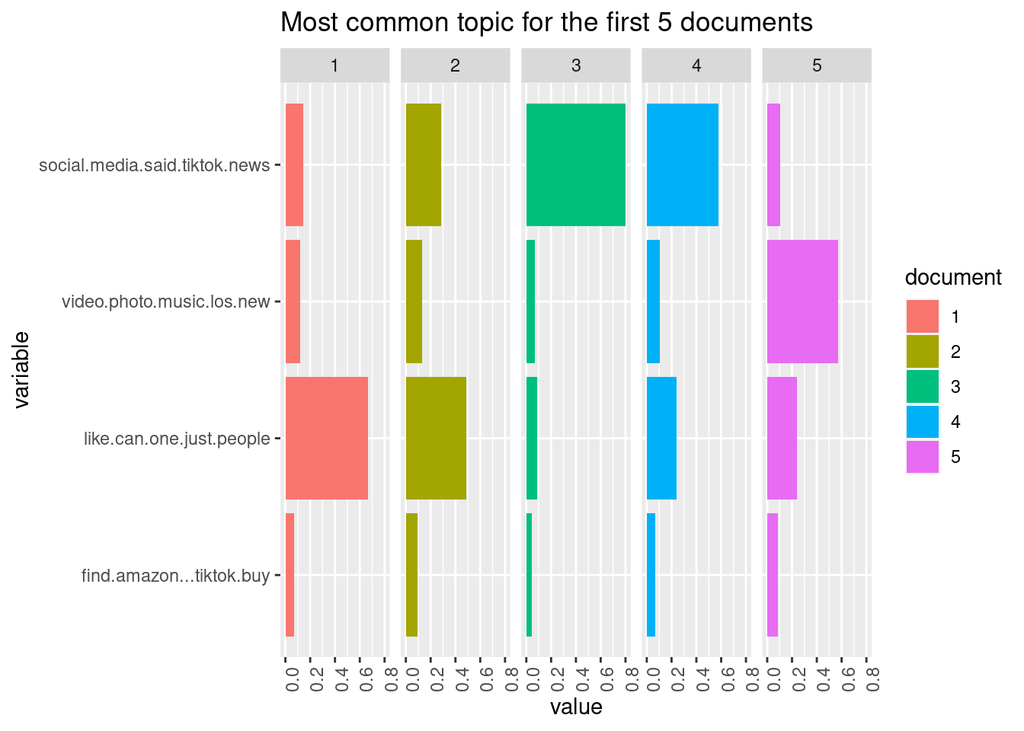

```r
#find top 5 words per topic
topic_words <- terms(topicModel_k4, 5)
# create topic_words into a character string vector
topic_names <- apply(topic_words, 2, paste, collapse = " ")


#specify # of examples to inspect
example_ids <- c(1:5)
n <- length(example_ids)

# get topic proportions from example documents
example_props <- theta_k4[example_ids, ]
colnames(example_props) <- topic_names #assign names to topics we are working with


#combine example topics with identifiers and melt to plotting form
viz_df <- melt(cbind(data.frame(example_props),
                     document = factor(1:n),
                     variable.names = "topic",
                     id.vars = "document"))

#create plot of distribution of each topic over each document
ggplot(data = viz_df, aes(variable,value, fill= document),
       ylab = "proportion") +
  geom_bar(stat = "identity") +
  theme(axis.text.x = element_text(angle = 90, hjust = 1)) +
  coord_flip() +
  facet_wrap(~document, ncol = n) +
  labs(title = "Most common topic for the first 5 documents")
```

5. Take a stab at interpreting the resulting topics. What are the key themes discussed in the articles in your data base?

**Answer**: The two main overarching theme from these results are political news in social media format (from topic 4) and entertaining media, most centered around Los Angeles (from topic 3). Because Tiktok is a big platformed used to sell products, topic 1 Top Ten words makes the most sense as most of the words can be related to stores you can buy products at as well as different products that are being advertised on the app.